# Ad Click Dataset

```python
# Import necessary libraries
import pandas as pd
import matplotlib.pyplot as plt
import seaborn as sns

# Load the dataset
file_path = 'C:/Users/Psycho Doc/Downloads/ad_click_dataset.csv'
df = pd.read_csv(file_path, encoding='ascii')

# Display the first few rows of the dataframe to understand its structure
print(df.head())

# Display basic information about the dataframe
df.info()
```

```
     id full_name   age      gender device_type ad_position browsing_history  \
0   670   User670  22.0         NaN     Desktop         Top         Shopping
1  3044  User3044   NaN        Male     Desktop         Top              NaN
2  5912  User5912  41.0  Non-Binary         NaN        Side        Education
3  5418  User5418  34.0        Male         NaN         NaN    Entertainment
4  9452  User9452  39.0  Non-Binary         NaN         NaN     Social Media

  time_of_day  click
0   Afternoon      1
1         NaN      1
2       Night      1
3     Evening      1
4     Morning      0
<class 'pandas.core.frame.DataFrame'>
RangeIndex: 10000 entries, 0 to 9999
Data columns (total 9 columns):
 #   Column            Non-Null Count  Dtype
---  ------            --------------  -----
 0   id                10000 non-null  int64
 1   full_name         10000 non-null  object
 2   age               5234 non-null   float64
 3   gender            5307 non-null   object
 4   device_type       8000 non-null   object
 5   ad_position       8000 non-null   object
 6   browsing_history  5218 non-null   object
 7   time_of_day       8000 non-null   object
 8   click             10000 non-null  int64
dtypes: float64(1), int64(2), object(6)
memory usage: 703.3+ KB
```

**A brief description of the datase**

The dataset contains 10,000 entries across 9 columns: 'id', 'full_name', 'age', 'gender', 'device_type', 'ad_position', 'browsing_history', 'time_of_day', and 'click'. The target variable, 'click', is binary, with 1 indicating a click and 0 indicating no click. Several columns contain missing values, particularly in 'age', 'gender', 'browsing_history', 'device_type', 'ad_position', and 'time_of_day'

```
Missing values:
id                     0
full_name              0
age                 4766
gender              4693
device_type         2000
ad_position         2000
browsing_history    4782
time_of_day         2000
click                  0
dtype: int64
```

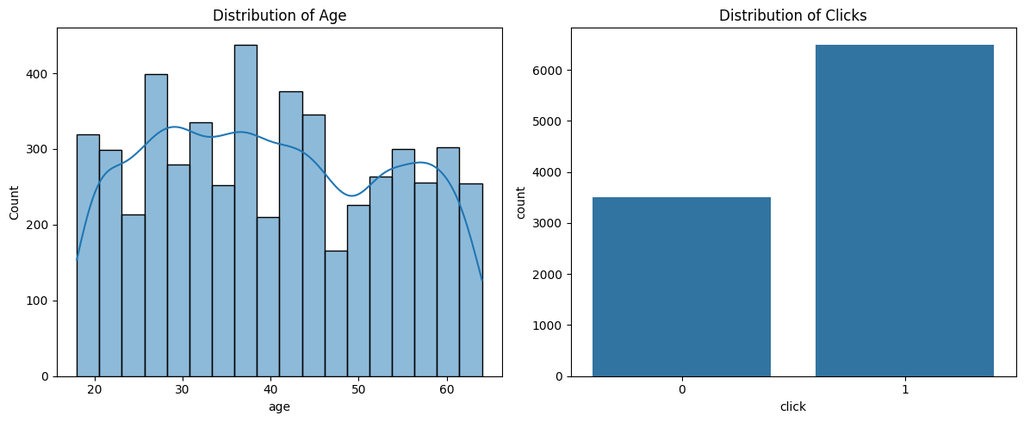

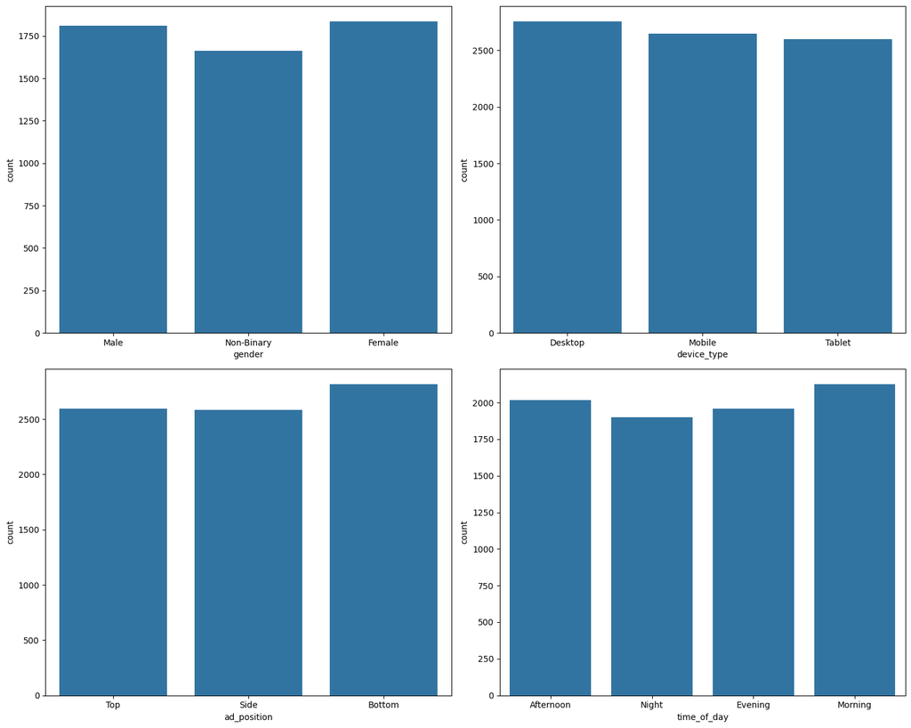

```
Correlation between age and click: -0.08205567770300844

Prepared data head:
     id full_name   age  gender  device_type  ad_position  browsing_history  \
0   670   User670  22.0       0            0            2                 3
1  3044  User3044  26.0       1            0            2                 1
2  5912  User5912  41.0       2            0            1                 0
3  5418  User5418  34.0       1            0            0                 1
4  9452  User9452  39.0       2            0            0                 4

   time_of_day click
0            0     1
1            2     1
2            3     1
3            1     1
4            2     0

Prepared data info:
<class 'pandas.core.frame.DataFrame'>
RangeIndex: 10000 entries, 0 to 9999
Data columns (total 9 columns):
 #   Column            Non-Null Count  Dtype
---  ------            --------------  -----
 0   id                10000 non-null  object
 1   full_name         10000 non-null  object
 2   age               10000 non-null  float64
 3   gender            10000 non-null  int64
 4   device_type       10000 non-null  int64
 5   ad_position       10000 non-null  int64
 6   browsing_history  10000 non-null  int64
 7   time_of_day       10000 non-null  int64
 8   click             10000 non-null  object
dtypes: float64(1), int64(5), object(3)
memory usage: 703.3+ KB
```

```python
import pandas as pd
import matplotlib.pyplot as plt
import seaborn as sns
from sklearn.impute import SimpleImputer
from sklearn.preprocessing import LabelEncoder

# Load the dataset
df = pd.read_csv("C:/Users/Psycho Doc/Downloads/ad_click_dataset.csv", encoding='ascii')

# Check for missing values
print("Missing values:")
print(df.isnull().sum())

# Plot distribution of numerical variables
fig, (ax1, ax2) = plt.subplots(1, 2, figsize=(12, 5))
sns.histplot(df['age'].dropna(), kde=True, ax=ax1)
ax1.set_title('Distribution of Age')
sns.countplot(x='click', data=df, ax=ax2)
ax2.set_title('Distribution of Clicks')
plt.tight_layout()
plt.show()

# Plot categorical variables
fig, axes = plt.subplots(2, 2, figsize=(15, 12))
sns.countplot(x='gender', data=df, ax=axes[0, 0])
sns.countplot(x='device_type', data=df, ax=axes[0, 1])
sns.countplot(x='ad_position', data=df, ax=axes[1, 0])
sns.countplot(x='time_of_day', data=df, ax=axes[1, 1])
plt.tight_layout()
plt.show()

# Correlation between age and click
correlation = df['age'].corr(df['click'])
print(f"Correlation between age and click: {correlation}")

# Prepare data for modeling
# Impute missing values
categorical_cols = ['gender', 'device_type', 'ad_position', 'browsing_history', 'time_of_day']

imputer = SimpleImputer(strategy='most_frequent')
df[df.columns] = imputer.fit_transform(df)

# Encode categorical variables
le = LabelEncoder()
for col in categorical_cols:
    df[col] = le.fit_transform(df[col].astype(str))

# Convert age to numeric, replacing any non-numeric values with NaN
df['age'] = pd.to_numeric(df['age'], errors='coerce')

# Fill NaN values in age with the mean
df.fillna({'age': df['age'].mean()}, inplace=True)

print("\nPrepared data head:")
print(df.head())

print("\nPrepared data info:")
df.info()
```